# Esquema Tesis v1

Antoine Thibaud

8 de noviembre de 2015

# Esquema Tesis

## Problema a analizar y objetivos del trabajo

### Estimación de cosecha en la República Argentina

#### Estimación de la superficie sembrada con cultivos extensivos

De acuerdo a “Método de Segmentos Aleatorios” [1], del Ministerio de Agricultura, Ganadería y Pesca (MAGyP), “la estimación de la superficie agrícola tiene una gran relevancia estratégica y es requerida por numerosos actores económicos, sociales y políticos para planificar acciones, reducir incertidumbre y mejorar la asignación de los recursos”.

“La estimación de la superficie sembrada de los principales cultivos extensivos en el país se llevó a cabo históricamente mediante el denominado ‘método subjetivo’, que consiste en relevar estimaciones de”informantes calificados… [y mejorarlos] a partir de la incorporación de controles y validaciones con datos provenientes de otras fuentes comerciales y productivas como ser acopiadores, cooperativas, productores, distribuidores de agroquímicos y semillas, etc."

Si bien sigue siendo necesario contar con informantes calificados, el Ministerio determinó la necesidad de corregir la subjetividad del método subjetivo: para ello desarrolló el denominado “Método de segmentos Aleatorios”.

#### Método de segmentos Aleatorios

El website del MAGyP explica que “este método contempla la utilización de técnicas de teledetección basadas en imágenes satelitales de alta y mediana resolución, integradas en un sistema de información geográfica (GIS), el control e interpretación de los resultados obtenidos a través de operativos a campo y el procesamiento y difusión de la información generada por la aplicación de esta metodología” y que “consiste en la selección de una muestra aleatoria de puntos dentro de estratos homogéneos predeterminados”.

#### El papel de las imágenes satelitales

[Desarrollar] A partir de una cantidad de puntos geográficos elegidos aleatoriamente, la imágenes satelitales de alta y mediana resolución (Landsat, Spot, Modis) y del programa del Google Earth para la ejecución de las siguientes tareas:  
* estratificación de zonas homogéneas  
* distribución de puntos sobre la superficie territorial  
* diseño de segmentos  
* delineado y especificación del uso de los lotes como verdad terrestre  
* medición exacta de las superficies seleccionadas y de las superficies para expandir la muestra

En otras palabras, las imágenes se utilizan en la preparación de los viajes a campo, para ubicar y delinear segmentos y Unidades de Uso de Suelo (UUS), que son los lotes individuales dentro de cada segmento. No tienen uso directo en la determinación de los cultivos ni en la estimación de la superficie sembrada de cada uno de ellos.

#### Un tema no resuelto: discriminación de cultivos en base a información satelital disponible

[Desarrollar] La idea de estimar las superficies cultivadas directamente a través del análisis de imágenes disponibles gratuitamente es tentadora. Esta posibilidad está hoy limitada por falta de una técnica adecuada para discriminar los diferentes cultivos en base a dichas imágenes. En conversaciones con diversos expertos, dos casos fueron nombrados en reiteradas oportunidades: **trigo vs. cebada** en la cosecha fina y **soja vs. maíz** en la cosecha gruesa.

[OJO, documentar este comentario de E. Basile] En países del hemisferio norte, las fechas de siembra son mucho más homogéneas que en la Argentina y esto permite mejorar estas estimaciones. En nuestro país, debido a […] estas fechas son muy escalonadas y a la fecha no se han desarrollado modelos que ayuden a estimar las superficies con la precisíon adecuada.

### Objetivo del trabajo

#### Enunciado

El objetivo de este trabajo fue investigar por diversos caminos si las técnicas de data mining permitían discriminar cultivos en la Pampa húmeda en base a fotos satelitales.

Debido a la importancia de la soja en la economía Argentina, decidí atacar específicamente el tema **soja vs. maíz** .

#### Precisión actual vs buscada

La precisión actual de las estimaciones del MAGyP en cuanto a superficie de soja se expresa en porcentaje a través del denominado coeficiente de variación (cv): es el cociente entre el error estándar y la estimación de las superficies de cada UUS. [Desarrollar]

Los cv que obtiene el MAGyP son muy buenos: para la soja, en la región sur de la Provincia de Santa Fé, rondan el 5%. Para otros cultivos, debido a que la superficie sembrada es mucho menor, el error sube y para el maíz, por ejemple, el cv sube a más de 15 o 20%.

[Consultar con Marcelo] Para estimar la calidad del modelo usé la ‘medida F’, es decir la media armónica entre la precisión y el recall.

#### Fecha en la que es preciso obtener resultados

Los viajes a campo para la cosecha fina se realizan entre octubre y noviembre. Los de la cosecha gruesa durante el mes de febrero. Estas son las fechas tempranas en las que un observador humano puede distinguir los diferentes cultivos [Verificar esta afirmación].

A estos viajes les sigue un trabajo manual que permite obtener las estimaciones: la duración de esta fase es de ¿2 semanas?

Con respecto a las fechas para obtener estimaciones de superficies sembradas, el objetivo es obtener un modelo con la performance adecuada en la misma fecha aproximada que los resultados actuales.

#### Estudio de la estabilidad del modelo y de su generalización

La agricultura es una actividad muy sensible a las variaciones climáticas. Otro objetivo de este trabajo fue estudiar la performance del modelo en otras cosechas. Esto es importante por dos motivos diferentes:  
* En los años lluviosos, la proporción de fotos con muchas nubes subirá: quise estudiar la degradación de la performance si, para las mismas campañas estudiadas, eliminaba cantidades crecientes de imágenes.  
* Además es de esperar que el desarrollo de las plantas sea diferente y que el modelo ya no sea adecuado: se estudió la performance en diferentes años.

También estudíé la performance que se podría obtener quince días y un mes antes de dicha fecha.

Se estudió la performance en otras zonas agrícolas, no tan favorables al cultivo de la soja: ¿dónde?

## Datos disponibles

Si bien las variables independientes se extraen de imágenes satelitales, la variable independiente para entrenar el modelo, la ‘verdad de campo’ proviene de otra fuente: se trata de los relevamientos del MAGyP.

Los datos recibidos provienen del corazón de la zona sojera.

### Departamentos

Provincia de Santa Fé, departamentos de Iriondo, San Jerónimo, San Martín y Belgrano.

Localización de los cuatro departamentos, leo el shapefile de departamentos recibido.

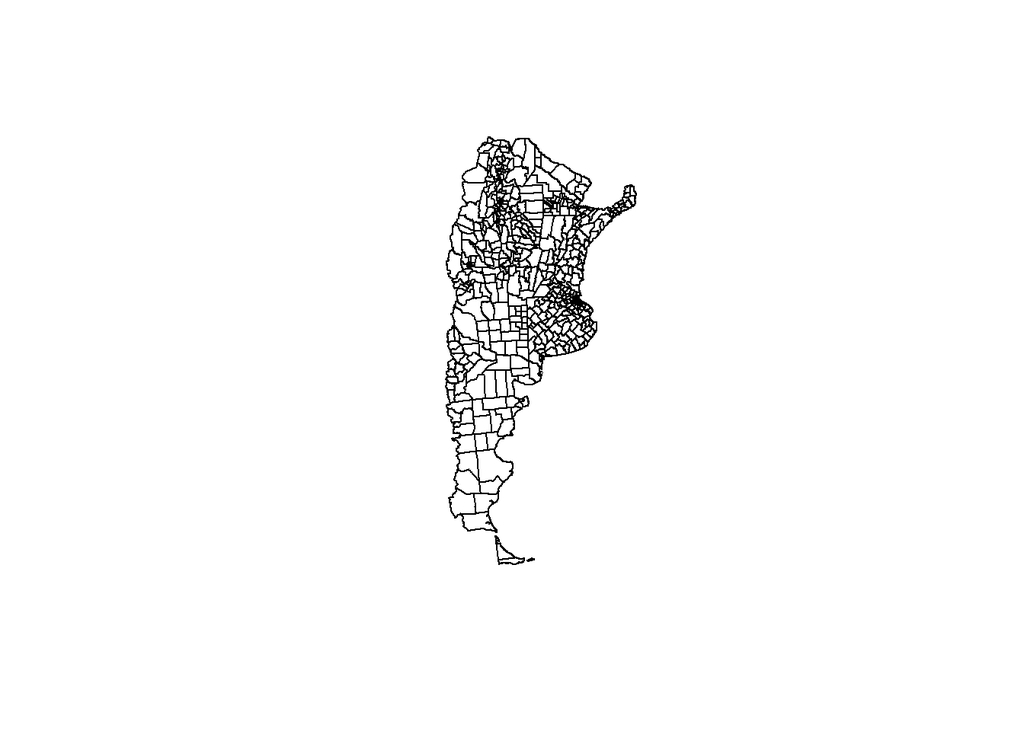

```r
departamentos <- readOGR(dsn = "./Departamentos shapefiles", layer = "deptos_f5", verbose = FALSE)
plot(departamentos)
```

El shapefile contiene todo el país, me quedo con los 4 departamentos de interés. La provincia de Sante Fé es el #82.

[figure not shown]

Expando la región de interés:

[figure not shown]

### Años más bien secos

Se usaron datos de las campañas 2012/2013 y 2013/2014 por tratarse de años de pocas lluvias, a fin de maximizar la cantidad de fotos sin nubes.

## Algunas intuiciones a desarrollar

La situación concreta es que los equipos técnicos del MAGyP saben que se ha intentado ograr la discriminación deseada pero que no se ha logrado resolver el problema. Asumo que el análisis de fotos puntuales de Landsat y/o Modis no tienen suficiente información como para diferenciar ambos cultivos.

### Agregar atributos

Diferentes fechas: podemos yuxtapones los datos de fotos en difentes fechas y calcular diferencias entre diferentes fotos.

DEM Las alturas de un pixel y la diferencia con los adyacentes pueden dar idea de la orientación de la pendiente, variable que podría incidir en las reflectancias detectadas.

Lotes referencia: podemos usar lotes ‘testigo’, por ejemplo de campos del INTA, en los que se sepa a ciencia cierta que corresponden a soja o a maíz. Podemos entonces agregar atributos que midan de alguna manera la ‘distancia’ de un píxel cuanquiera a estas referencias. Esto le debería dar cierta estabilidad al modelo frente a cambios climáticos de año a año.

Otros satelites: podemos combinar información de otra fuentes, por ejemplo Modis y/o Spot, cuidando de considerar los aspectos relacionados con el tamaño del pixel.

### Búsqueda de interacciones y alinealidades

Si necesario el agregado de variables ‘razonadas’, no es menos necesario algún proceso de expansión y posterior selección de atributos.  
Por este motivo se puso especial énfasis en algoritmos que automatizan este proceso de selección, en particular SVM y NN.

### Problemas de georeferenciación

Es común que cuando se superpone un archivo georeferenciado sobre un Google Map o sobre Google Earth, se noten pequeñas diferencias de posición: un camino puede estar desplazado varios metros. Habrá que estudiar cuidadosamente que los píxeles de diferentes fuentes realmente correspondan al mismo punto físico.

### Problemas de nubes

En el caso de fotos con nubes, tendremos datos faltantes en los datos, que intentaremos rellenar: lo podemos hacer interpolando la foto anterior y la posterior. Podemos tener varias situaciones:  
- Que la foto sea la última disponible: se repetirá - Que una pequeña zona esté tapada por las nubes, pero que una parte importante de la foto se encuentre libre de ellas: se interpolaran los datos siguiendo la misma proporción que los lotes visibles. - Que toda la foto esté tapada por las nubes: la interpolación será lineal.

### Trabajo en dos etapas

1. Situación más favorable para detectar posibles mecanismos de diferenciación: Se extajeron únicamente datos de lotes claramente identificados como maíz o como soja de primera a fin de estudiar distribuciones e identificar posibles interacciones que permitiesen separar ambas poblaciones. En ésta no se intentó buscar intervalos de confianza ni bondad de ajuste, sino únicamente buscar mecanismos posibles de separación.
2. Una vez lograda esta separación, se estudiaron los segmentos completos a fin de separar también los demás cultivos.

## Algoritmos

### Etapa 1

1. Regresión logística: se consideraron las variables ‘directas’ con un proceso de regularización a fin de evitar inestabilidades del modelo. No se esperaba demasiado de este modelo sino que la idea era conocer el ‘piso’ para el problema.
2. SVM
3. Red neuronal (una o dos capas ocultas como máximo)
4. [No sé si tiene sentido, pero sería divertido probar…] Deep learning

### Etapa 2

Los mejor de la etapa 1, pero ahora discriminando otro tipo de cultivos (por ejemplo girasol) o pasturas o zonas habitadas…